# Introduction

## Table of Contents:

- Part 0: Setup
- Part 1: Data Scraping/Tidying
- Part 2: Data Visualization
- Part 3: Results/Verification
- Part 4: Conclusion

## Part 0: Setup

In order to walk through this tutorial, you will need the following libraries:

- numpy
- pandas
- seaborn
- pyplot
- lxml

All of these libraries come preinstalled in Anaconda which also runs Python 3.6 so before you progress, I suggest installing that and opening this via Jupyter Notebook which comes preinstalled with Anaconda!

## Part 1: Data Scraping/Tidying

```python
import numpy as np
import pandas as pd
import seaborn as sns
import matplotlib.pyplot as plt
import requests
import lxml.html as lh
import re
import warnings
from collections import Counter
from io import StringIO
from IPython.display import Image
warnings.filterwarnings("ignore")
```

```python
pokemon = pd.read_csv('Pokemon.csv')
pokemon
```

|  | # | Name | Type 1 | Type 2 | Total | HP | Attack | Defense | Sp. Atk | Sp. Def | Speed | Generation | Legendary |
| --- | --- | --- | --- | --- | --- | --- | --- | --- | --- | --- | --- | --- | --- |
| 0 | 1 | Bulbasaur | Grass | Poison | 318 | 45 | 49 | 49 | 65 | 65 | 45 | 1 | False |
| 1 | 2 | Ivysaur | Grass | Poison | 405 | 60 | 62 | 63 | 80 | 80 | 60 | 1 | False |
| 2 | 3 | Venusaur | Grass | Poison | 525 | 80 | 82 | 83 | 100 | 100 | 80 | 1 | False |
| 3 | 3 | VenusaurMega Venusaur | Grass | Poison | 625 | 80 | 100 | 123 | 122 | 120 | 80 | 1 | False |
| 4 | 4 | Charmander | Fire | NaN | 309 | 39 | 52 | 43 | 60 | 50 | 65 | 1 | False |
| 5 | 5 | Charmeleon | Fire | NaN | 405 | 58 | 64 | 58 | 80 | 65 | 80 | 1 | False |
| 6 | 6 | Charizard | Fire | Flying | 534 | 78 | 84 | 78 | 109 | 85 | 100 | 1 | False |
| 7 | 6 | CharizardMega Charizard X | Fire | Dragon | 634 | 78 | 130 | 111 | 130 | 85 | 100 | 1 | False |
| 8 | 6 | CharizardMega Charizard Y | Fire | Flying | 634 | 78 | 104 | 78 | 159 | 115 | 100 | 1 | False |
| 9 | 7 | Squirtle | Water | NaN | 314 | 44 | 48 | 65 | 50 | 64 | 43 | 1 | False |
| 10 | 8 | Wartortle | Water | NaN | 405 | 59 | 63 | 80 | 65 | 80 | 58 | 1 | False |
| 11 | 9 | Blastoise | Water | NaN | 530 | 79 | 83 | 100 | 85 | 105 | 78 | 1 | False |
| 12 | 9 | BlastoiseMega Blastoise | Water | NaN | 630 | 79 | 103 | 120 | 135 | 115 | 78 | 1 | False |
| 13 | 10 | Caterpie | Bug | NaN | 195 | 45 | 30 | 35 | 20 | 20 | 45 | 1 | False |
| 14 | 11 | Metapod | Bug | NaN | 205 | 50 | 20 | 55 | 25 | 25 | 30 | 1 | False |
| 15 | 12 | Butterfree | Bug | Flying | 395 | 60 | 45 | 50 | 90 | 80 | 70 | 1 | False |
| 16 | 13 | Weedle | Bug | Poison | 195 | 40 | 35 | 30 | 20 | 20 | 50 | 1 | False |
| 17 | 14 | Kakuna | Bug | Poison | 205 | 45 | 25 | 50 | 25 | 25 | 35 | 1 | False |
| 18 | 15 | Beedrill | Bug | Poison | 395 | 65 | 90 | 40 | 45 | 80 | 75 | 1 | False |
| 19 | 15 | BeedrillMega Beedrill | Bug | Poison | 495 | 65 | 150 | 40 | 15 | 80 | 145 | 1 | False |
| 20 | 16 | Pidgey | Normal | Flying | 251 | 40 | 45 | 40 | 35 | 35 | 56 | 1 | False |
| 21 | 17 | Pidgeotto | Normal | Flying | 349 | 63 | 60 | 55 | 50 | 50 | 71 | 1 | False |
| 22 | 18 | Pidgeot | Normal | Flying | 479 | 83 | 80 | 75 | 70 | 70 | 101 | 1 | False |
| 23 | 18 | PidgeotMega Pidgeot | Normal | Flying | 579 | 83 | 80 | 80 | 135 | 80 | 121 | 1 | False |
| 24 | 19 | Rattata | Normal | NaN | 253 | 30 | 56 | 35 | 25 | 35 | 72 | 1 | False |
| 25 | 20 | Raticate | Normal | NaN | 413 | 55 | 81 | 60 | 50 | 70 | 97 | 1 | False |
| 26 | 21 | Spearow | Normal | Flying | 262 | 40 | 60 | 30 | 31 | 31 | 70 | 1 | False |
| 27 | 22 | Fearow | Normal | Flying | 442 | 65 | 90 | 65 | 61 | 61 | 100 | 1 | False |
| 28 | 23 | Ekans | Poison | NaN | 288 | 35 | 60 | 44 | 40 | 54 | 55 | 1 | False |
| 29 | 24 | Arbok | Poison | NaN | 438 | 60 | 85 | 69 | 65 | 79 | 80 | 1 | False |
| ... | ... | ... | ... | ... | ... | ... | ... | ... | ... | ... | ... | ... | ... |
| 770 | 700 | Sylveon | Fairy | NaN | 525 | 95 | 65 | 65 | 110 | 130 | 60 | 6 | False |
| 771 | 701 | Hawlucha | Fighting | Flying | 500 | 78 | 92 | 75 | 74 | 63 | 118 | 6 | False |
| 772 | 702 | Dedenne | Electric | Fairy | 431 | 67 | 58 | 57 | 81 | 67 | 101 | 6 | False |
| 773 | 703 | Carbink | Rock | Fairy | 500 | 50 | 50 | 150 | 50 | 150 | 50 | 6 | False |
| 774 | 704 | Goomy | Dragon | NaN | 300 | 45 | 50 | 35 | 55 | 75 | 40 | 6 | False |
| 775 | 705 | Sliggoo | Dragon | NaN | 452 | 68 | 75 | 53 | 83 | 113 | 60 | 6 | False |
| 776 | 706 | Goodra | Dragon | NaN | 600 | 90 | 100 | 70 | 110 | 150 | 80 | 6 | False |
| 777 | 707 | Klefki | Steel | Fairy | 470 | 57 | 80 | 91 | 80 | 87 | 75 | 6 | False |
| 778 | 708 | Phantump | Ghost | Grass | 309 | 43 | 70 | 48 | 50 | 60 | 38 | 6 | False |
| 779 | 709 | Trevenant | Ghost | Grass | 474 | 85 | 110 | 76 | 65 | 82 | 56 | 6 | False |
| 780 | 710 | PumpkabooAverage Size | Ghost | Grass | 335 | 49 | 66 | 70 | 44 | 55 | 51 | 6 | False |
| 781 | 710 | PumpkabooSmall Size | Ghost | Grass | 335 | 44 | 66 | 70 | 44 | 55 | 56 | 6 | False |
| 782 | 710 | PumpkabooLarge Size | Ghost | Grass | 335 | 54 | 66 | 70 | 44 | 55 | 46 | 6 | False |
| 783 | 710 | PumpkabooSuper Size | Ghost | Grass | 335 | 59 | 66 | 70 | 44 | 55 | 41 | 6 | False |
| 784 | 711 | GourgeistAverage Size | Ghost | Grass | 494 | 65 | 90 | 122 | 58 | 75 | 84 | 6 | False |
| 785 | 711 | GourgeistSmall Size | Ghost | Grass | 494 | 55 | 85 | 122 | 58 | 75 | 99 | 6 | False |
| 786 | 711 | GourgeistLarge Size | Ghost | Grass | 494 | 75 | 95 | 122 | 58 | 75 | 69 | 6 | False |
| 787 | 711 | GourgeistSuper Size | Ghost | Grass | 494 | 85 | 100 | 122 | 58 | 75 | 54 | 6 | False |
| 788 | 712 | Bergmite | Ice | NaN | 304 | 55 | 69 | 85 | 32 | 35 | 28 | 6 | False |
| 789 | 713 | Avalugg | Ice | NaN | 514 | 95 | 117 | 184 | 44 | 46 | 28 | 6 | False |
| 790 | 714 | Noibat | Flying | Dragon | 245 | 40 | 30 | 35 | 45 | 40 | 55 | 6 | False |
| 791 | 715 | Noivern | Flying | Dragon | 535 | 85 | 70 | 80 | 97 | 80 | 123 | 6 | False |
| 792 | 716 | Xerneas | Fairy | NaN | 680 | 126 | 131 | 95 | 131 | 98 | 99 | 6 | True |
| 793 | 717 | Yveltal | Dark | Flying | 680 | 126 | 131 | 95 | 131 | 98 | 99 | 6 | True |
| 794 | 718 | Zygarde50% Forme | Dragon | Ground | 600 | 108 | 100 | 121 | 81 | 95 | 95 | 6 | True |
| 795 | 719 | Diancie | Rock | Fairy | 600 | 50 | 100 | 150 | 100 | 150 | 50 | 6 | True |
| 796 | 719 | DiancieMega Diancie | Rock | Fairy | 700 | 50 | 160 | 110 | 160 | 110 | 110 | 6 | True |
| 797 | 720 | HoopaHoopa Confined | Psychic | Ghost | 600 | 80 | 110 | 60 | 150 | 130 | 70 | 6 | True |
| 798 | 720 | HoopaHoopa Unbound | Psychic | Dark | 680 | 80 | 160 | 60 | 170 | 130 | 80 | 6 | True |
| 799 | 721 | Volcanion | Fire | Water | 600 | 80 | 110 | 120 | 130 | 90 | 70 | 6 | True |

800 rows × 13 columns

So here we have the dataset which lists all 721 pokemon and their individual stats, type(s), generation, and whether they are legendary or not. You can use any Pokemon from the first 251 to battle each other as those are the only ones currently available in the game. In the future, as the developers add more Pokemon to the game, I can simply change the size of the dataset and continue through the tutorial.

Contrary to popular belief, the best team does not just consist of the Pokemon with the best stats. The Pokemon's type and move set also play a large role in which Pokemon will win. For example, Pokemon A might have a more powerful attack, but if Pokemon B has a higher defense and speed, then it will likely defeat A. Since we don't have a pokemon's moveset included in the dataset, let's try to scrape that data from the web.

```python
url='http://www.eurogamer.net/articles/2017-11-06-pokemon-go-moves-movesets-move-list-and-highest-dps-attacks'
page = requests.get(url)
doc = lh.fromstring(page.content)
tbody_elements = doc.xpath('//tbody')
num_pokemon = [len(T) for T in tbody_elements[:1]]
num_pokemon
```

```
[251]
```

As shown by the output above, it is confirmed that there are 251 move lists available which is the same as the number of Pokemon in our dataset. So now we can extract the data and put it in a dataframe in order to easily manage the data.

```python
tr_elements = doc.xpath('//tbody')
data = []
i = 0
for t in tr_elements[0]:
    i+=1
    name=t.text_content()
    data.append((name,[]))
temp = ["Moves"]

for i in range(251):
    data_new = re.sub(' +',' ',data[i][0]).split('\n')
    data_new = data_new[-6:]
    data_new = ",".join(data_new)
    temp.append(data_new)
temp = "\n".join(temp)

moveset = pd.read_csv(pd.compat.StringIO(temp), sep="\n")
moveset['#s'] = [y for y in range(1,252)]
moveset = moveset[['#s','Moves']]
moveset
```

|  | #s | Moves |
| --- | --- | --- |
| 0 | 1 | Tackle (10) ,Vine Whip (11.67) , Sludge Bomb ... |
| 1 | 2 | Razor Leaf (13) ,Vine Whip (11.67) , Sludge B... |
| 2 | 3 | Razor Leaf (13) ,Vine Whip (11.67) , Sludge B... |
| 3 | 4 | Ember (10) ,Scratch (12) , Flame Burst (26.92... |
| 4 | 5 | Ember (10) ,Fire Fang (12.22) , Flame Burst (... |
| 5 | 6 | Fire Spin (12.73) ,Air Slash (11.67) , Fire B... |
| 6 | 7 | Tackle (10) ,Bubble (10) , Aqua Jet (17.31) ,... |
| 7 | 8 | Bite (12) ,Water Gun (10) , Aqua Jet (17.31) ... |
| 8 | 9 | Bite (12) ,Water Gun (10) , Ice Beam (27.27) ... |
| 9 | 10 | Caterpie, Bug, Tackle (10) ,Bug Bite (10) , S... |
| 10 | 11 | Metapod, Bug, Tackle (10) ,Bug Bite (10) , St... |
| 11 | 12 | Struggle Bug (10) ,Confusion (12.5) , Psychic... |
| 12 | 13 | Weedle, Bug, Bug Bite (10) ,Poison Sting (8.3... |
| 13 | 14 | Kakuna, Bug, Bug Bite (10) ,Poison Sting (8.3... |
| 14 | 15 | Infestation (9.09) ,Poison Jab (12.5) , Aeria... |
| 15 | 16 | Tackle (10) ,Quick Attack (10) , Twister (16.... |
| 16 | 17 | Wing Attack (10) ,Steel Wing (13.75) , Twiste... |
| 17 | 18 | Air Slash (11.67) ,Steel Wing (13.75) , Hurri... |
| 18 | 19 | Tackle (10) ,Quick Attack (10) , Dig (21.28) ... |
| 19 | 20 | Bite (12) ,Quick Attack (10) , Dig (21.28) ,H... |
| 20 | 21 | Quick Attack (10) ,Peck (10) , Aerial Ace (22... |
| 21 | 22 | Steel Wing (13.75) ,Peck (10) , Aerial Ace (2... |
| 22 | 23 | Acid (11.25) ,Poison Sting (8.33) , Wrap (20.... |
| 23 | 24 | Acid (11.25) ,Bite (12) , Dark Pulse (26.67) ... |
| 24 | 25 | Thunder Shock (8.33) ,Quick Attack (10) , Dis... |
| 25 | 26 | Volt Switch (8.7) ,Spark (8.57) , Brick Break... |
| 26 | 27 | Scratch (12) ,Mud Shot (8.33) , Dig (21.28) ,... |
| 27 | 28 | Metal Claw (11.43) ,Mud Shot (8.33) , Rock To... |
| 28 | 29 | Poison Sting (8.33) ,Bite (12) , Poison Fang ... |
| 29 | 30 | Poison Sting (8.33) ,Bite (12) , Poison Fang ... |
| ... | ... | ... |
| 221 | 222 | Tackle (10) ,Bubble (10) , Rock Blast (23.81)... |
| 222 | 223 | Water Gun (10) ,Mud Shot (8.33) , Aurora Beam... |
| 223 | 224 | Water Gun (10) ,Mud Shot (8.33) , Gunk Shot (... |
| 224 | 225 | Ice Shard (10) ,Quick Attack (10) , Ice Punch... |
| 225 | 226 | Bubble (10) ,Wing Attack (10) , Water Pulse (... |
| 226 | 227 | Steel Wing (13.75) ,Air Slash (11.67) , Brave... |
| 227 | 228 | Feint Attack (11.11) ,Ember (10) , Crunch (21... |
| 228 | 229 | Snarl (11.91) ,Fire Fang (12.22) , Crunch (21... |
| 229 | 230 | Water Gun (10) ,Dragon Breath (12) , Hydro Pu... |
| 230 | 231 | Tackle (10) ,Rock Smash (11.54) , Bulldoze (2... |
| 231 | 232 | Tackle (10) ,Counter (13.33) , Earthquake (33... |
| 232 | 233 | Hidden Power (10) ,Charge Beam (7.27) , Solar... |
| 233 | 234 | Tackle (10) ,Zen Headbutt (10.91) , Stomp (32... |
| 234 | 235 | Smeargle, Normal, Tackle (10) ,Struggle (15.9... |
| 235 | 236 | Rock Smash (11.54) ,Tackle (10) , Brick Break... |
| 236 | 237 | Rock Smash (11.54) ,Counter (13.33) , Close C... |
| 237 | 238 | Powder Snow (6) ,Pound (11.67) , Ice Beam (27... |
| 238 | 239 | Thunder Shock (8.33) ,Low Kick (10) , Thunder... |
| 239 | 240 | Ember (10) ,Karate Chop (10) , Brick Break (2... |
| 240 | 241 | Tackle (10) ,Zen Headbutt (10.91) , Stomp (32... |
| 241 | 242 | Pound (11.67) ,Zen Headbutt (10.91) , Psychic... |
| 242 | 243 | Thunder Shock (8.33) ,Volt Switch (8.7) , Thu... |
| 243 | 244 | Fire Spin (12.73) ,Fire Fang (12.22) , Flamet... |
| 244 | 245 | Extrasensory (10.91) ,Snarl (11.91) , Hydro P... |
| 245 | 246 | Bite (12) ,Rock Smash (11.54) , Stomp (32.35)... |
| 246 | 247 | Bite (12) ,Rock Smash (11.54) , Dig (21.28) ,... |
| 247 | 248 | Bite (12) ,Iron Tail (13.64) , Fire Blast (33... |
| 248 | 249 | Extrasensory (10.91) ,Dragon Tail (13.64) , S... |
| 249 | 250 | Extrasensory (10.91) ,Steel Wing (13.75) , Br... |
| 250 | 251 | Confusion (12.5) ,Charge Beam (7.27) , Hyper ... |

251 rows × 2 columns

Nice! Now that we have a dataframe containing the Pokemon number and its moves, we can simply merge the two dataframes together since they are of the same size. Then we can do a bit of cleaning up and remove the unnecessary columns.

```python
pkmn_copy = pokemon
pokemon = pokemon.drop_duplicates(subset=['#'], keep="first")
pokemon = pokemon.reset_index(drop=True)
firstandsecondgen = pokemon.head(n=251)

frames = [firstandsecondgen,moveset]
pkmn = pd.concat(frames, axis=1)
pkmn = pkmn.drop(["#s"],axis=1)
pkmn_stats = pkmn.drop(["#","Moves","Generation"],axis=1)
pkmn_stats = pkmn_stats.drop(["Legendary"],axis=1)
pkmn_stats = pkmn_stats.sort_index(ascending=True)

#pkmn
pkmn_stats
```

|  | Name | Type 1 | Type 2 | Total | HP | Attack | Defense | Sp. Atk | Sp. Def | Speed |
| --- | --- | --- | --- | --- | --- | --- | --- | --- | --- | --- |
| 0 | Bulbasaur | Grass | Poison | 318 | 45 | 49 | 49 | 65 | 65 | 45 |
| 1 | Ivysaur | Grass | Poison | 405 | 60 | 62 | 63 | 80 | 80 | 60 |
| 2 | Venusaur | Grass | Poison | 525 | 80 | 82 | 83 | 100 | 100 | 80 |
| 3 | Charmander | Fire | NaN | 309 | 39 | 52 | 43 | 60 | 50 | 65 |
| 4 | Charmeleon | Fire | NaN | 405 | 58 | 64 | 58 | 80 | 65 | 80 |
| 5 | Charizard | Fire | Flying | 534 | 78 | 84 | 78 | 109 | 85 | 100 |
| 6 | Squirtle | Water | NaN | 314 | 44 | 48 | 65 | 50 | 64 | 43 |
| 7 | Wartortle | Water | NaN | 405 | 59 | 63 | 80 | 65 | 80 | 58 |
| 8 | Blastoise | Water | NaN | 530 | 79 | 83 | 100 | 85 | 105 | 78 |
| 9 | Caterpie | Bug | NaN | 195 | 45 | 30 | 35 | 20 | 20 | 45 |
| 10 | Metapod | Bug | NaN | 205 | 50 | 20 | 55 | 25 | 25 | 30 |
| 11 | Butterfree | Bug | Flying | 395 | 60 | 45 | 50 | 90 | 80 | 70 |
| 12 | Weedle | Bug | Poison | 195 | 40 | 35 | 30 | 20 | 20 | 50 |
| 13 | Kakuna | Bug | Poison | 205 | 45 | 25 | 50 | 25 | 25 | 35 |
| 14 | Beedrill | Bug | Poison | 395 | 65 | 90 | 40 | 45 | 80 | 75 |
| 15 | Pidgey | Normal | Flying | 251 | 40 | 45 | 40 | 35 | 35 | 56 |
| 16 | Pidgeotto | Normal | Flying | 349 | 63 | 60 | 55 | 50 | 50 | 71 |
| 17 | Pidgeot | Normal | Flying | 479 | 83 | 80 | 75 | 70 | 70 | 101 |
| 18 | Rattata | Normal | NaN | 253 | 30 | 56 | 35 | 25 | 35 | 72 |
| 19 | Raticate | Normal | NaN | 413 | 55 | 81 | 60 | 50 | 70 | 97 |
| 20 | Spearow | Normal | Flying | 262 | 40 | 60 | 30 | 31 | 31 | 70 |
| 21 | Fearow | Normal | Flying | 442 | 65 | 90 | 65 | 61 | 61 | 100 |
| 22 | Ekans | Poison | NaN | 288 | 35 | 60 | 44 | 40 | 54 | 55 |
| 23 | Arbok | Poison | NaN | 438 | 60 | 85 | 69 | 65 | 79 | 80 |
| 24 | Pikachu | Electric | NaN | 320 | 35 | 55 | 40 | 50 | 50 | 90 |
| 25 | Raichu | Electric | NaN | 485 | 60 | 90 | 55 | 90 | 80 | 110 |
| 26 | Sandshrew | Ground | NaN | 300 | 50 | 75 | 85 | 20 | 30 | 40 |
| 27 | Sandslash | Ground | NaN | 450 | 75 | 100 | 110 | 45 | 55 | 65 |
| 28 | Nidoran♀ | Poison | NaN | 275 | 55 | 47 | 52 | 40 | 40 | 41 |
| 29 | Nidorina | Poison | NaN | 365 | 70 | 62 | 67 | 55 | 55 | 56 |
| ... | ... | ... | ... | ... | ... | ... | ... | ... | ... | ... |
| 221 | Corsola | Water | Rock | 380 | 55 | 55 | 85 | 65 | 85 | 35 |
| 222 | Remoraid | Water | NaN | 300 | 35 | 65 | 35 | 65 | 35 | 65 |
| 223 | Octillery | Water | NaN | 480 | 75 | 105 | 75 | 105 | 75 | 45 |
| 224 | Delibird | Ice | Flying | 330 | 45 | 55 | 45 | 65 | 45 | 75 |
| 225 | Mantine | Water | Flying | 465 | 65 | 40 | 70 | 80 | 140 | 70 |
| 226 | Skarmory | Steel | Flying | 465 | 65 | 80 | 140 | 40 | 70 | 70 |
| 227 | Houndour | Dark | Fire | 330 | 45 | 60 | 30 | 80 | 50 | 65 |
| 228 | Houndoom | Dark | Fire | 500 | 75 | 90 | 50 | 110 | 80 | 95 |
| 229 | Kingdra | Water | Dragon | 540 | 75 | 95 | 95 | 95 | 95 | 85 |
| 230 | Phanpy | Ground | NaN | 330 | 90 | 60 | 60 | 40 | 40 | 40 |
| 231 | Donphan | Ground | NaN | 500 | 90 | 120 | 120 | 60 | 60 | 50 |
| 232 | Porygon2 | Normal | NaN | 515 | 85 | 80 | 90 | 105 | 95 | 60 |
| 233 | Stantler | Normal | NaN | 465 | 73 | 95 | 62 | 85 | 65 | 85 |
| 234 | Smeargle | Normal | NaN | 250 | 55 | 20 | 35 | 20 | 45 | 75 |
| 235 | Tyrogue | Fighting | NaN | 210 | 35 | 35 | 35 | 35 | 35 | 35 |
| 236 | Hitmontop | Fighting | NaN | 455 | 50 | 95 | 95 | 35 | 110 | 70 |
| 237 | Smoochum | Ice | Psychic | 305 | 45 | 30 | 15 | 85 | 65 | 65 |
| 238 | Elekid | Electric | NaN | 360 | 45 | 63 | 37 | 65 | 55 | 95 |
| 239 | Magby | Fire | NaN | 365 | 45 | 75 | 37 | 70 | 55 | 83 |
| 240 | Miltank | Normal | NaN | 490 | 95 | 80 | 105 | 40 | 70 | 100 |
| 241 | Blissey | Normal | NaN | 540 | 255 | 10 | 10 | 75 | 135 | 55 |
| 242 | Raikou | Electric | NaN | 580 | 90 | 85 | 75 | 115 | 100 | 115 |
| 243 | Entei | Fire | NaN | 580 | 115 | 115 | 85 | 90 | 75 | 100 |
| 244 | Suicune | Water | NaN | 580 | 100 | 75 | 115 | 90 | 115 | 85 |
| 245 | Larvitar | Rock | Ground | 300 | 50 | 64 | 50 | 45 | 50 | 41 |
| 246 | Pupitar | Rock | Ground | 410 | 70 | 84 | 70 | 65 | 70 | 51 |
| 247 | Tyranitar | Rock | Dark | 600 | 100 | 134 | 110 | 95 | 100 | 61 |
| 248 | Lugia | Psychic | Flying | 680 | 106 | 90 | 130 | 90 | 154 | 110 |
| 249 | Ho-oh | Fire | Flying | 680 | 106 | 130 | 90 | 110 | 154 | 90 |
| 250 | Celebi | Psychic | Grass | 600 | 100 | 100 | 100 | 100 | 100 | 100 |

251 rows × 10 columns

We have reached the end of Part 1 where we end with two dataframes: one that contains all the information merged together and a smaller dataframe (displayed above) that only contains the stats of each Pokemon. To display one or the other, simply uncomment the line that is commented and comment out the one below it. In the next part, we shall tidy the data a bit in order to visually represent it.

## Part 2: Data Visualization

Generally, you want the fastest Pokemon with the strongest attack and strongest defense for it to be considered well rounded. Here is a quick explanation of all the various columns:

# : ID for each Pokemon

Name: Name of each Pokemon

Type 1: Each Pokemon has a type, this determines weakness/resistance to attacks

Type 2: 2nd type of Pokemon (will not be used in this tutorial!)

Total: sum of all stats which gives a general idea of a Pokemon's overall strength

HP: hit points, or health, defines how much damage a Pokemon can withstand before fainting

Attack: the base modifier for normal attacks (eg. Scratch, Punch)

Defense: the base damage resistance against normal attacks

SP Atk: special attack, the base modifier for special attacks (e.g. fire blast, bubble beam)

SP Def: the base damage resistance against special attacks

Speed: determines which Pokemon attacks first each round

In this section, I shall begin visualizing the data in order to get a better overall understanding of whether certain types of Pokemon are better than others. I'll start by tidying up the data in order to plot the the individual values of the stats.

```python
statVSvals = pd.melt(pkmn_stats, id_vars=["Name", "Type 1", "Type 2"], var_name="Stat")
statVSvals_copy = statVSvals
statVSvals_copy = statVSvals_copy.drop(statVSvals_copy.index[0:251])
statVSvals_copy
```

|  | Name | Type 1 | Type 2 | Stat | value |
| --- | --- | --- | --- | --- | --- |
| 251 | Bulbasaur | Grass | Poison | HP | 45 |
| 252 | Ivysaur | Grass | Poison | HP | 60 |
| 253 | Venusaur | Grass | Poison | HP | 80 |
| 254 | Charmander | Fire | NaN | HP | 39 |
| 255 | Charmeleon | Fire | NaN | HP | 58 |
| 256 | Charizard | Fire | Flying | HP | 78 |
| 257 | Squirtle | Water | NaN | HP | 44 |
| 258 | Wartortle | Water | NaN | HP | 59 |
| 259 | Blastoise | Water | NaN | HP | 79 |
| 260 | Caterpie | Bug | NaN | HP | 45 |
| 261 | Metapod | Bug | NaN | HP | 50 |
| 262 | Butterfree | Bug | Flying | HP | 60 |
| 263 | Weedle | Bug | Poison | HP | 40 |
| 264 | Kakuna | Bug | Poison | HP | 45 |
| 265 | Beedrill | Bug | Poison | HP | 65 |
| 266 | Pidgey | Normal | Flying | HP | 40 |
| 267 | Pidgeotto | Normal | Flying | HP | 63 |
| 268 | Pidgeot | Normal | Flying | HP | 83 |
| 269 | Rattata | Normal | NaN | HP | 30 |
| 270 | Raticate | Normal | NaN | HP | 55 |
| 271 | Spearow | Normal | Flying | HP | 40 |
| 272 | Fearow | Normal | Flying | HP | 65 |
| 273 | Ekans | Poison | NaN | HP | 35 |
| 274 | Arbok | Poison | NaN | HP | 60 |
| 275 | Pikachu | Electric | NaN | HP | 35 |
| 276 | Raichu | Electric | NaN | HP | 60 |
| 277 | Sandshrew | Ground | NaN | HP | 50 |
| 278 | Sandslash | Ground | NaN | HP | 75 |
| 279 | Nidoran♀ | Poison | NaN | HP | 55 |
| 280 | Nidorina | Poison | NaN | HP | 70 |
| ... | ... | ... | ... | ... | ... |
| 1727 | Corsola | Water | Rock | Speed | 35 |
| 1728 | Remoraid | Water | NaN | Speed | 65 |
| 1729 | Octillery | Water | NaN | Speed | 45 |
| 1730 | Delibird | Ice | Flying | Speed | 75 |
| 1731 | Mantine | Water | Flying | Speed | 70 |
| 1732 | Skarmory | Steel | Flying | Speed | 70 |
| 1733 | Houndour | Dark | Fire | Speed | 65 |
| 1734 | Houndoom | Dark | Fire | Speed | 95 |
| 1735 | Kingdra | Water | Dragon | Speed | 85 |
| 1736 | Phanpy | Ground | NaN | Speed | 40 |
| 1737 | Donphan | Ground | NaN | Speed | 50 |
| 1738 | Porygon2 | Normal | NaN | Speed | 60 |
| 1739 | Stantler | Normal | NaN | Speed | 85 |
| 1740 | Smeargle | Normal | NaN | Speed | 75 |
| 1741 | Tyrogue | Fighting | NaN | Speed | 35 |
| 1742 | Hitmontop | Fighting | NaN | Speed | 70 |
| 1743 | Smoochum | Ice | Psychic | Speed | 65 |
| 1744 | Elekid | Electric | NaN | Speed | 95 |
| 1745 | Magby | Fire | NaN | Speed | 83 |
| 1746 | Miltank | Normal | NaN | Speed | 100 |
| 1747 | Blissey | Normal | NaN | Speed | 55 |
| 1748 | Raikou | Electric | NaN | Speed | 115 |
| 1749 | Entei | Fire | NaN | Speed | 100 |
| 1750 | Suicune | Water | NaN | Speed | 85 |
| 1751 | Larvitar | Rock | Ground | Speed | 41 |
| 1752 | Pupitar | Rock | Ground | Speed | 51 |
| 1753 | Tyranitar | Rock | Dark | Speed | 61 |
| 1754 | Lugia | Psychic | Flying | Speed | 110 |
| 1755 | Ho-oh | Fire | Flying | Speed | 90 |
| 1756 | Celebi | Psychic | Grass | Speed | 100 |

1506 rows × 5 columns

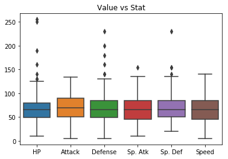

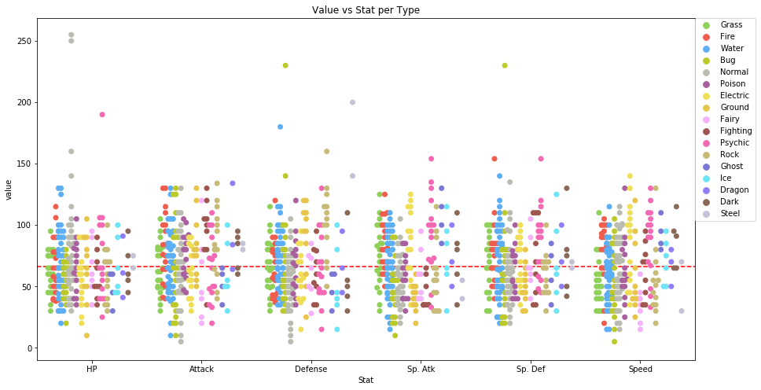

```python
temp = pkmn_stats.drop(["Total"],axis=1)
sns.boxplot(data=temp)
plt.title('Value vs Stat')
plt.show()

with sns.color_palette([
    "#8ED752", "#F95643", "#53AFFE", "#C3D221", "#BBBDAF",
    "#AD5CA2", "#F8E64E", "#F0CA42", "#F9AEFE", "#A35449",
    "#FB61B4", "#CDBD72", "#7673DA", "#66EBFF", "#8B76FF",
    "#8E6856", "#C3C1D7", "#75A4F9"], desat=.9):
    plt.figure(figsize=(15,8))
    sns.swarmplot(x="Stat", y="value", data=statVSvals_copy, hue="Type 1", dodge=True, size=7)
    plt.legend(bbox_to_anchor=(1, 1), loc=2, borderaxespad=0.)
    plt.title('Value vs Stat per Type')
    plt.axhline(pkmn['Speed'].mean(),color='red',linestyle='dashed')
    plt.show()
```

So we have 2 plots shown above. The first one is a boxplot that shows the overall distribution of individual stats of all the Pokemon which is useful as it shows us the min, max, and mean in each category. By eyeballing this plot you can see means for all the categories seem to be around 70 which can be verified by using the dataframe.describe() function. This is valuable information as it shows us that there are a lot of pokemon that are not viable options when trying to defeat the Top Tier Pokemon. So for this reason, we can use the mean total value of all the stats and create a filter to only consider Pokemon with a certain total value.

The second plot is a scatterplot that shows a breakdown of Pokemon type in each category. This gives us a much more detailed view of what the boxplot showed as it shows that certain pokemon are better in certain categories. For example, here we can see that Electric pokemon tend to have the lowest HP of all the different types but tend to fare better in the Speed stat. This gives us a rudimentary understanding of which Pokemon will win in a certain category based on its type.

```python
statVSvals_copy.describe()
```

|  | value |
| --- | --- |
| count | 1506.000000 |
| mean | 67.786853 |
| std | 28.284442 |
| min | 5.000000 |
| 25% | 48.000000 |
| 50% | 65.000000 |
| 75% | 85.000000 |
| max | 255.000000 |

So I'll round down the mean to 67 and multiply that by 6 to get a mean total of 402 which will now be used as the cutoff for Pokemon I am looking for. As I mentioned previously, a Pokemon with the highest total is not always the best for the job. This is where the type of Pokemon comes into play. So to quickly summarize, certain types of Pokemon are more effective against others. They largely follow some basic natural law principles like water is 2x effective against fire and electricity is completely ineffective against ground types. To read more about which types are most effective against each other click http://www.eurogamer.net/articles/2017-12-15-pokemon-go-type-chart-effectiveness-weaknesses. Because of this, I will add the stat multipliers for each Pokemon to show how effective it will be against a Pokemon of a different type and its own type.

```python
types = pd.read_csv(StringIO("""Attacking,Normal,Fire,Water,Electric,Grass,Ice,Fighting,Poison,Ground,Flying,Psychic,Bug,Rock,Ghost,Dragon,Dark,Steel,Fairy
Normal,1,1,1,1,1,1,1,1,1,1,1,1,0.5,0,1,1,0.5,1
Fire,1,0.5,0.5,1,2,2,1,1,1,1,1,2,0.5,1,0.5,1,2,1
Water,1,2,0.5,1,0.5,1,1,1,2,1,1,1,2,1,0.5,1,1,1
Electric,1,1,2,0.5,0.5,1,1,1,0,2,1,1,1,1,0.5,1,1,1
Grass,1,0.5,2,1,0.5,1,1,0.5,2,0.5,1,0.5,2,1,0.5,1,0.5,1
Ice,1,0.5,0.5,1,2,0.5,1,1,2,2,1,1,1,1,2,1,0.5,1
Fighting,2,1,1,1,1,2,1,0.5,1,0.5,0.5,0.5,2,0,1,2,2,0.5
Poison,1,1,1,1,2,1,1,0.5,0.5,1,1,1,0.5,0.5,1,1,0,2
Ground,1,2,1,2,0.5,1,1,2,1,0,1,0.5,2,1,1,1,2,1
Flying,1,1,1,0.5,2,1,2,1,1,1,1,2,0.5,1,1,1,0.5,1
Psychic,1,1,1,1,1,1,2,2,1,1,0.5,1,1,1,1,0,0.5,1
Bug,1,0.5,1,1,2,1,0.5,0.5,1,0.5,2,1,1,0.5,1,2,0.5,0.5
Rock,1,2,1,1,1,2,0.5,1,0.5,2,1,2,1,1,1,1,0.5,1
Ghost,0,1,1,1,1,1,1,1,1,1,2,1,1,2,1,0.5,1,1
Dragon,1,1,1,1,1,1,1,1,1,1,1,1,1,1,2,1,0.5,0
Dark,1,1,1,1,1,1,0.5,1,1,1,2,1,1,2,1,0.5,1,0.5
Steel,1,0.5,0.5,0.5,1,2,1,1,1,1,1,1,2,1,1,1,0.5,2
Fairy,1,0.5,1,1,1,1,2,0.5,1,1,1,1,1,1,2,2,0.5,1"""))

pkmn_atk = pkmn_stats.merge(types, left_on='Type 1', right_on='Attacking')
pkmn_atk = pkmn_atk.drop(["Attacking"],axis=1)
pkmn_atk = pkmn_atk.sort_values(['Total'], ascending=[True])
pkmn_trimmed = pkmn_atk[pkmn_atk['Total'] > 402]
pkmn_trimmed =  pkmn_trimmed.sort_index(ascending=True)

pkmn_trimmed
```

|  | Name | Type 1 | Type 2 | Total | HP | Attack | Defense | Sp. Atk | Sp. Def | Speed | ... | Ground | Flying | Psychic | Bug | Rock | Ghost | Dragon | Dark | Steel | Fairy |
| --- | --- | --- | --- | --- | --- | --- | --- | --- | --- | --- | --- | --- | --- | --- | --- | --- | --- | --- | --- | --- | --- |
| 1 | Ivysaur | Grass | Poison | 405 | 60 | 62 | 63 | 80 | 80 | 60 | ... | 2.0 | 0.5 | 1.0 | 0.5 | 2.0 | 1.0 | 0.5 | 1.0 | 0.5 | 1.0 |
| 2 | Venusaur | Grass | Poison | 525 | 80 | 82 | 83 | 100 | 100 | 80 | ... | 2.0 | 0.5 | 1.0 | 0.5 | 2.0 | 1.0 | 0.5 | 1.0 | 0.5 | 1.0 |
| 5 | Vileplume | Grass | Poison | 490 | 75 | 80 | 85 | 110 | 90 | 50 | ... | 2.0 | 0.5 | 1.0 | 0.5 | 2.0 | 1.0 | 0.5 | 1.0 | 0.5 | 1.0 |
| 8 | Victreebel | Grass | Poison | 490 | 80 | 105 | 65 | 100 | 70 | 70 | ... | 2.0 | 0.5 | 1.0 | 0.5 | 2.0 | 1.0 | 0.5 | 1.0 | 0.5 | 1.0 |
| 10 | Exeggutor | Grass | Psychic | 520 | 95 | 95 | 85 | 125 | 65 | 55 | ... | 2.0 | 0.5 | 1.0 | 0.5 | 2.0 | 1.0 | 0.5 | 1.0 | 0.5 | 1.0 |
| 11 | Tangela | Grass | NaN | 435 | 65 | 55 | 115 | 100 | 40 | 60 | ... | 2.0 | 0.5 | 1.0 | 0.5 | 2.0 | 1.0 | 0.5 | 1.0 | 0.5 | 1.0 |
| 13 | Bayleef | Grass | NaN | 405 | 60 | 62 | 80 | 63 | 80 | 60 | ... | 2.0 | 0.5 | 1.0 | 0.5 | 2.0 | 1.0 | 0.5 | 1.0 | 0.5 | 1.0 |
| 14 | Meganium | Grass | NaN | 525 | 80 | 82 | 100 | 83 | 100 | 80 | ... | 2.0 | 0.5 | 1.0 | 0.5 | 2.0 | 1.0 | 0.5 | 1.0 | 0.5 | 1.0 |
| 15 | Bellossom | Grass | NaN | 490 | 75 | 80 | 95 | 90 | 100 | 50 | ... | 2.0 | 0.5 | 1.0 | 0.5 | 2.0 | 1.0 | 0.5 | 1.0 | 0.5 | 1.0 |
| 18 | Jumpluff | Grass | Flying | 460 | 75 | 55 | 70 | 55 | 95 | 110 | ... | 2.0 | 0.5 | 1.0 | 0.5 | 2.0 | 1.0 | 0.5 | 1.0 | 0.5 | 1.0 |
| 20 | Sunflora | Grass | NaN | 425 | 75 | 75 | 55 | 105 | 85 | 30 | ... | 2.0 | 0.5 | 1.0 | 0.5 | 2.0 | 1.0 | 0.5 | 1.0 | 0.5 | 1.0 |
| 22 | Charmeleon | Fire | NaN | 405 | 58 | 64 | 58 | 80 | 65 | 80 | ... | 1.0 | 1.0 | 1.0 | 2.0 | 0.5 | 1.0 | 0.5 | 1.0 | 2.0 | 1.0 |
| 23 | Charizard | Fire | Flying | 534 | 78 | 84 | 78 | 109 | 85 | 100 | ... | 1.0 | 1.0 | 1.0 | 2.0 | 0.5 | 1.0 | 0.5 | 1.0 | 2.0 | 1.0 |
| 25 | Ninetales | Fire | NaN | 505 | 73 | 76 | 75 | 81 | 100 | 100 | ... | 1.0 | 1.0 | 1.0 | 2.0 | 0.5 | 1.0 | 0.5 | 1.0 | 2.0 | 1.0 |
| 27 | Arcanine | Fire | NaN | 555 | 90 | 110 | 80 | 100 | 80 | 95 | ... | 1.0 | 1.0 | 1.0 | 2.0 | 0.5 | 1.0 | 0.5 | 1.0 | 2.0 | 1.0 |
| 28 | Ponyta | Fire | NaN | 410 | 50 | 85 | 55 | 65 | 65 | 90 | ... | 1.0 | 1.0 | 1.0 | 2.0 | 0.5 | 1.0 | 0.5 | 1.0 | 2.0 | 1.0 |
| 29 | Rapidash | Fire | NaN | 500 | 65 | 100 | 70 | 80 | 80 | 105 | ... | 1.0 | 1.0 | 1.0 | 2.0 | 0.5 | 1.0 | 0.5 | 1.0 | 2.0 | 1.0 |
| 30 | Magmar | Fire | NaN | 495 | 65 | 95 | 57 | 100 | 85 | 93 | ... | 1.0 | 1.0 | 1.0 | 2.0 | 0.5 | 1.0 | 0.5 | 1.0 | 2.0 | 1.0 |
| 31 | Flareon | Fire | NaN | 525 | 65 | 130 | 60 | 95 | 110 | 65 | ... | 1.0 | 1.0 | 1.0 | 2.0 | 0.5 | 1.0 | 0.5 | 1.0 | 2.0 | 1.0 |
| 32 | Moltres | Fire | Flying | 580 | 90 | 100 | 90 | 125 | 85 | 90 | ... | 1.0 | 1.0 | 1.0 | 2.0 | 0.5 | 1.0 | 0.5 | 1.0 | 2.0 | 1.0 |
| 34 | Quilava | Fire | NaN | 405 | 58 | 64 | 58 | 80 | 65 | 80 | ... | 1.0 | 1.0 | 1.0 | 2.0 | 0.5 | 1.0 | 0.5 | 1.0 | 2.0 | 1.0 |
| 35 | Typhlosion | Fire | NaN | 534 | 78 | 84 | 78 | 109 | 85 | 100 | ... | 1.0 | 1.0 | 1.0 | 2.0 | 0.5 | 1.0 | 0.5 | 1.0 | 2.0 | 1.0 |
| 37 | Magcargo | Fire | Rock | 410 | 50 | 50 | 120 | 80 | 80 | 30 | ... | 1.0 | 1.0 | 1.0 | 2.0 | 0.5 | 1.0 | 0.5 | 1.0 | 2.0 | 1.0 |
| 39 | Entei | Fire | NaN | 580 | 115 | 115 | 85 | 90 | 75 | 100 | ... | 1.0 | 1.0 | 1.0 | 2.0 | 0.5 | 1.0 | 0.5 | 1.0 | 2.0 | 1.0 |
| 40 | Ho-oh | Fire | Flying | 680 | 106 | 130 | 90 | 110 | 154 | 90 | ... | 1.0 | 1.0 | 1.0 | 2.0 | 0.5 | 1.0 | 0.5 | 1.0 | 2.0 | 1.0 |
| 42 | Wartortle | Water | NaN | 405 | 59 | 63 | 80 | 65 | 80 | 58 | ... | 2.0 | 1.0 | 1.0 | 1.0 | 2.0 | 1.0 | 0.5 | 1.0 | 1.0 | 1.0 |
| 43 | Blastoise | Water | NaN | 530 | 79 | 83 | 100 | 85 | 105 | 78 | ... | 2.0 | 1.0 | 1.0 | 1.0 | 2.0 | 1.0 | 0.5 | 1.0 | 1.0 | 1.0 |
| 45 | Golduck | Water | NaN | 500 | 80 | 82 | 78 | 95 | 80 | 85 | ... | 2.0 | 1.0 | 1.0 | 1.0 | 2.0 | 1.0 | 0.5 | 1.0 | 1.0 | 1.0 |
| 48 | Poliwrath | Water | Fighting | 510 | 90 | 95 | 95 | 70 | 90 | 70 | ... | 2.0 | 1.0 | 1.0 | 1.0 | 2.0 | 1.0 | 0.5 | 1.0 | 1.0 | 1.0 |
| 50 | Tentacruel | Water | Poison | 515 | 80 | 70 | 65 | 80 | 120 | 100 | ... | 2.0 | 1.0 | 1.0 | 1.0 | 2.0 | 1.0 | 0.5 | 1.0 | 1.0 | 1.0 |
| ... | ... | ... | ... | ... | ... | ... | ... | ... | ... | ... | ... | ... | ... | ... | ... | ... | ... | ... | ... | ... | ... |
| 207 | Hypno | Psychic | NaN | 483 | 85 | 73 | 70 | 73 | 115 | 67 | ... | 1.0 | 1.0 | 0.5 | 1.0 | 1.0 | 1.0 | 1.0 | 0.0 | 0.5 | 1.0 |
| 208 | Mr. Mime | Psychic | Fairy | 460 | 40 | 45 | 65 | 100 | 120 | 90 | ... | 1.0 | 1.0 | 0.5 | 1.0 | 1.0 | 1.0 | 1.0 | 0.0 | 0.5 | 1.0 |
| 209 | Mewtwo | Psychic | NaN | 680 | 106 | 110 | 90 | 154 | 90 | 130 | ... | 1.0 | 1.0 | 0.5 | 1.0 | 1.0 | 1.0 | 1.0 | 0.0 | 0.5 | 1.0 |
| 210 | Mew | Psychic | NaN | 600 | 100 | 100 | 100 | 100 | 100 | 100 | ... | 1.0 | 1.0 | 0.5 | 1.0 | 1.0 | 1.0 | 1.0 | 0.0 | 0.5 | 1.0 |
| 212 | Xatu | Psychic | Flying | 470 | 65 | 75 | 70 | 95 | 70 | 95 | ... | 1.0 | 1.0 | 0.5 | 1.0 | 1.0 | 1.0 | 1.0 | 0.0 | 0.5 | 1.0 |
| 213 | Espeon | Psychic | NaN | 525 | 65 | 65 | 60 | 130 | 95 | 110 | ... | 1.0 | 1.0 | 0.5 | 1.0 | 1.0 | 1.0 | 1.0 | 0.0 | 0.5 | 1.0 |
| 215 | Wobbuffet | Psychic | NaN | 405 | 190 | 33 | 58 | 33 | 58 | 33 | ... | 1.0 | 1.0 | 0.5 | 1.0 | 1.0 | 1.0 | 1.0 | 0.0 | 0.5 | 1.0 |
| 216 | Lugia | Psychic | Flying | 680 | 106 | 90 | 130 | 90 | 154 | 110 | ... | 1.0 | 1.0 | 0.5 | 1.0 | 1.0 | 1.0 | 1.0 | 0.0 | 0.5 | 1.0 |
| 217 | Celebi | Psychic | Grass | 600 | 100 | 100 | 100 | 100 | 100 | 100 | ... | 1.0 | 1.0 | 0.5 | 1.0 | 1.0 | 1.0 | 1.0 | 0.0 | 0.5 | 1.0 |
| 220 | Golem | Rock | Ground | 495 | 80 | 120 | 130 | 55 | 65 | 45 | ... | 0.5 | 2.0 | 1.0 | 2.0 | 1.0 | 1.0 | 1.0 | 1.0 | 0.5 | 1.0 |
| 223 | Omastar | Rock | Water | 495 | 70 | 60 | 125 | 115 | 70 | 55 | ... | 0.5 | 2.0 | 1.0 | 2.0 | 1.0 | 1.0 | 1.0 | 1.0 | 0.5 | 1.0 |
| 225 | Kabutops | Rock | Water | 495 | 60 | 115 | 105 | 65 | 70 | 80 | ... | 0.5 | 2.0 | 1.0 | 2.0 | 1.0 | 1.0 | 1.0 | 1.0 | 0.5 | 1.0 |
| 226 | Aerodactyl | Rock | Flying | 515 | 80 | 105 | 65 | 60 | 75 | 130 | ... | 0.5 | 2.0 | 1.0 | 2.0 | 1.0 | 1.0 | 1.0 | 1.0 | 0.5 | 1.0 |
| 227 | Sudowoodo | Rock | NaN | 410 | 70 | 100 | 115 | 30 | 65 | 30 | ... | 0.5 | 2.0 | 1.0 | 2.0 | 1.0 | 1.0 | 1.0 | 1.0 | 0.5 | 1.0 |
| 229 | Pupitar | Rock | Ground | 410 | 70 | 84 | 70 | 65 | 70 | 51 | ... | 0.5 | 2.0 | 1.0 | 2.0 | 1.0 | 1.0 | 1.0 | 1.0 | 0.5 | 1.0 |
| 230 | Tyranitar | Rock | Dark | 600 | 100 | 134 | 110 | 95 | 100 | 61 | ... | 0.5 | 2.0 | 1.0 | 2.0 | 1.0 | 1.0 | 1.0 | 1.0 | 0.5 | 1.0 |
| 232 | Haunter | Ghost | Poison | 405 | 45 | 50 | 45 | 115 | 55 | 95 | ... | 1.0 | 1.0 | 2.0 | 1.0 | 1.0 | 2.0 | 1.0 | 0.5 | 1.0 | 1.0 |
| 233 | Gengar | Ghost | Poison | 500 | 60 | 65 | 60 | 130 | 75 | 110 | ... | 1.0 | 1.0 | 2.0 | 1.0 | 1.0 | 2.0 | 1.0 | 0.5 | 1.0 | 1.0 |
| 234 | Misdreavus | Ghost | NaN | 435 | 60 | 60 | 60 | 85 | 85 | 85 | ... | 1.0 | 1.0 | 2.0 | 1.0 | 1.0 | 2.0 | 1.0 | 0.5 | 1.0 | 1.0 |
| 235 | Jynx | Ice | Psychic | 455 | 65 | 50 | 35 | 115 | 95 | 95 | ... | 2.0 | 2.0 | 1.0 | 1.0 | 1.0 | 1.0 | 2.0 | 1.0 | 0.5 | 1.0 |
| 236 | Articuno | Ice | Flying | 580 | 90 | 85 | 100 | 95 | 125 | 85 | ... | 2.0 | 2.0 | 1.0 | 1.0 | 1.0 | 1.0 | 2.0 | 1.0 | 0.5 | 1.0 |
| 238 | Piloswine | Ice | Ground | 450 | 100 | 100 | 80 | 60 | 60 | 50 | ... | 2.0 | 2.0 | 1.0 | 1.0 | 1.0 | 1.0 | 2.0 | 1.0 | 0.5 | 1.0 |
| 242 | Dragonair | Dragon | NaN | 420 | 61 | 84 | 65 | 70 | 70 | 70 | ... | 1.0 | 1.0 | 1.0 | 1.0 | 1.0 | 1.0 | 2.0 | 1.0 | 0.5 | 0.0 |
| 243 | Dragonite | Dragon | Flying | 600 | 91 | 134 | 95 | 100 | 100 | 80 | ... | 1.0 | 1.0 | 1.0 | 1.0 | 1.0 | 1.0 | 2.0 | 1.0 | 0.5 | 0.0 |
| 244 | Umbreon | Dark | NaN | 525 | 95 | 65 | 110 | 60 | 130 | 65 | ... | 1.0 | 1.0 | 2.0 | 1.0 | 1.0 | 2.0 | 1.0 | 0.5 | 1.0 | 0.5 |
| 245 | Murkrow | Dark | Flying | 405 | 60 | 85 | 42 | 85 | 42 | 91 | ... | 1.0 | 1.0 | 2.0 | 1.0 | 1.0 | 2.0 | 1.0 | 0.5 | 1.0 | 0.5 |
| 246 | Sneasel | Dark | Ice | 430 | 55 | 95 | 55 | 35 | 75 | 115 | ... | 1.0 | 1.0 | 2.0 | 1.0 | 1.0 | 2.0 | 1.0 | 0.5 | 1.0 | 0.5 |
| 248 | Houndoom | Dark | Fire | 500 | 75 | 90 | 50 | 110 | 80 | 95 | ... | 1.0 | 1.0 | 2.0 | 1.0 | 1.0 | 2.0 | 1.0 | 0.5 | 1.0 | 0.5 |
| 249 | Steelix | Steel | Ground | 510 | 75 | 85 | 200 | 55 | 65 | 30 | ... | 1.0 | 1.0 | 1.0 | 1.0 | 2.0 | 1.0 | 1.0 | 1.0 | 0.5 | 2.0 |
| 250 | Skarmory | Steel | Flying | 465 | 65 | 80 | 140 | 40 | 70 | 70 | ... | 1.0 | 1.0 | 1.0 | 1.0 | 2.0 | 1.0 | 1.0 | 1.0 | 0.5 | 2.0 |

140 rows × 28 columns

Now from the table above we can see that there are only 140 Pokemon that fit our new criteria and we have added the stat multipliers to each row of the table. In order for this information to become useful, we must normalize the data in order to find the strongest in category against a Top Tier Pokemon. Feel free to change the Top Tier Pokemon value!

```python
# Top Tier Pokemon: Dragonite, Tyranitar, Blissey, Machamp, Vaporeon, Heracross, Jolteon, Snorlax, Lapras, Exeggutor
# replace pk1 = 'X' with any of the above Pokemon
pk1 = "Vaporeon"

opponent_type = pkmn_trimmed[pkmn_trimmed['Name'] == pk1]['Type 1'].iloc[0]
opponent_multiplier = pkmn_trimmed[opponent_type]
adjusted_attack = pkmn_trimmed['Attack'] * opponent_multiplier
adjusted_defense = pkmn_trimmed['Defense'] * opponent_multiplier
adjusted_spAtk = pkmn_trimmed['Sp. Atk'] * opponent_multiplier
adjusted_spDef = pkmn_trimmed['Sp. Def'] * opponent_multiplier
adjusted_Speed = pkmn_trimmed['Speed'] * opponent_multiplier

pkmn_trimmed['Adjusted Attack'] = (adjusted_attack - adjusted_attack.min()) / (adjusted_attack.max() - adjusted_attack.min()) * 100
pkmn_trimmed['Adjusted Defense'] = (adjusted_defense - adjusted_defense.min()) / (adjusted_defense.max() - adjusted_defense.min()) * 100
pkmn_trimmed['Adjusted Sp. Atk'] = (adjusted_spAtk - adjusted_spAtk.min()) / (adjusted_spAtk.max() - adjusted_spAtk.min()) * 100
pkmn_trimmed['Adjusted Sp. Def'] = (adjusted_spDef - adjusted_spDef.min()) / (adjusted_spDef.max() - adjusted_spDef.min()) * 100
pkmn_trimmed['Adjusted Speed'] = (adjusted_Speed - adjusted_Speed.min()) / (adjusted_Speed.max() - adjusted_Speed.min()) * 100
pkmn_trimmed['Adjusted Total'] = pkmn_trimmed['Adjusted Attack'] + pkmn_trimmed['Adjusted Defense'] + pkmn_trimmed['Adjusted Sp. Atk'] + pkmn_trimmed['Adjusted Sp. Def'] + pkmn_trimmed['Adjusted Speed']
pkmn_trimmed = pkmn_trimmed.sort_index(ascending=True)
pkmn_trimmed
```

|  | Name | Type 1 | Type 2 | Total | HP | Attack | Defense | Sp. Atk | Sp. Def | Speed | ... | Dragon | Dark | Steel | Fairy | Adjusted Attack | Adjusted Defense | Adjusted Sp. Atk | Adjusted Sp. Def | Adjusted Speed | Adjusted Total |
| --- | --- | --- | --- | --- | --- | --- | --- | --- | --- | --- | --- | --- | --- | --- | --- | --- | --- | --- | --- | --- | --- |
| 1 | Ivysaur | Grass | Poison | 405 | 60 | 62 | 63 | 80 | 80 | 60 | ... | 0.5 | 1.0 | 0.5 | 1.0 | 58.048780 | 53.777778 | 62.500000 | 66.265060 | 41.818182 | 282.409800 |
| 2 | Venusaur | Grass | Poison | 525 | 80 | 82 | 83 | 100 | 100 | 80 | ... | 0.5 | 1.0 | 0.5 | 1.0 | 77.560976 | 71.555556 | 79.166667 | 85.542169 | 56.363636 | 370.189003 |
| 5 | Vileplume | Grass | Poison | 490 | 75 | 80 | 85 | 110 | 90 | 50 | ... | 0.5 | 1.0 | 0.5 | 1.0 | 75.609756 | 73.333333 | 87.500000 | 75.903614 | 34.545455 | 346.892158 |
| 8 | Victreebel | Grass | Poison | 490 | 80 | 105 | 65 | 100 | 70 | 70 | ... | 0.5 | 1.0 | 0.5 | 1.0 | 100.000000 | 55.555556 | 79.166667 | 56.626506 | 49.090909 | 340.439637 |
| 10 | Exeggutor | Grass | Psychic | 520 | 95 | 95 | 85 | 125 | 65 | 55 | ... | 0.5 | 1.0 | 0.5 | 1.0 | 90.243902 | 73.333333 | 100.000000 | 51.807229 | 38.181818 | 353.566283 |
| 11 | Tangela | Grass | NaN | 435 | 65 | 55 | 115 | 100 | 40 | 60 | ... | 0.5 | 1.0 | 0.5 | 1.0 | 51.219512 | 100.000000 | 79.166667 | 27.710843 | 41.818182 | 299.915204 |
| 13 | Bayleef | Grass | NaN | 405 | 60 | 62 | 80 | 63 | 80 | 60 | ... | 0.5 | 1.0 | 0.5 | 1.0 | 58.048780 | 68.888889 | 48.333333 | 66.265060 | 41.818182 | 283.354245 |
| 14 | Meganium | Grass | NaN | 525 | 80 | 82 | 100 | 83 | 100 | 80 | ... | 0.5 | 1.0 | 0.5 | 1.0 | 77.560976 | 86.666667 | 65.000000 | 85.542169 | 56.363636 | 371.133447 |
| 15 | Bellossom | Grass | NaN | 490 | 75 | 80 | 95 | 90 | 100 | 50 | ... | 0.5 | 1.0 | 0.5 | 1.0 | 75.609756 | 82.222222 | 70.833333 | 85.542169 | 34.545455 | 348.752935 |
| 18 | Jumpluff | Grass | Flying | 460 | 75 | 55 | 70 | 55 | 95 | 110 | ... | 0.5 | 1.0 | 0.5 | 1.0 | 51.219512 | 60.000000 | 41.666667 | 80.722892 | 78.181818 | 311.790889 |
| 20 | Sunflora | Grass | NaN | 425 | 75 | 75 | 55 | 105 | 85 | 30 | ... | 0.5 | 1.0 | 0.5 | 1.0 | 70.731707 | 46.666667 | 83.333333 | 71.084337 | 20.000000 | 291.816045 |
| 22 | Charmeleon | Fire | NaN | 405 | 58 | 64 | 58 | 80 | 65 | 80 | ... | 0.5 | 1.0 | 2.0 | 1.0 | 13.170732 | 10.666667 | 12.500000 | 4.819277 | 12.727273 | 53.883948 |
| 23 | Charizard | Fire | Flying | 534 | 78 | 84 | 78 | 109 | 85 | 100 | ... | 0.5 | 1.0 | 2.0 | 1.0 | 18.048780 | 15.111111 | 18.541667 | 9.638554 | 16.363636 | 77.703749 |
| 25 | Ninetales | Fire | NaN | 505 | 73 | 76 | 75 | 81 | 100 | 100 | ... | 0.5 | 1.0 | 2.0 | 1.0 | 16.097561 | 14.444444 | 12.708333 | 13.253012 | 16.363636 | 72.866987 |
| 27 | Arcanine | Fire | NaN | 555 | 90 | 110 | 80 | 100 | 80 | 95 | ... | 0.5 | 1.0 | 2.0 | 1.0 | 24.390244 | 15.555556 | 16.666667 | 8.433735 | 15.454545 | 80.500747 |
| 28 | Ponyta | Fire | NaN | 410 | 50 | 85 | 55 | 65 | 65 | 90 | ... | 0.5 | 1.0 | 2.0 | 1.0 | 18.292683 | 10.000000 | 9.375000 | 4.819277 | 14.545455 | 57.032415 |
| 29 | Rapidash | Fire | NaN | 500 | 65 | 100 | 70 | 80 | 80 | 105 | ... | 0.5 | 1.0 | 2.0 | 1.0 | 21.951220 | 13.333333 | 12.500000 | 8.433735 | 17.272727 | 73.491015 |
| 30 | Magmar | Fire | NaN | 495 | 65 | 95 | 57 | 100 | 85 | 93 | ... | 0.5 | 1.0 | 2.0 | 1.0 | 20.731707 | 10.444444 | 16.666667 | 9.638554 | 15.090909 | 72.572282 |
| 31 | Flareon | Fire | NaN | 525 | 65 | 130 | 60 | 95 | 110 | 65 | ... | 0.5 | 1.0 | 2.0 | 1.0 | 29.268293 | 11.111111 | 15.625000 | 15.662651 | 10.000000 | 81.667054 |
| 32 | Moltres | Fire | Flying | 580 | 90 | 100 | 90 | 125 | 85 | 90 | ... | 0.5 | 1.0 | 2.0 | 1.0 | 21.951220 | 17.777778 | 21.875000 | 9.638554 | 14.545455 | 85.788006 |
| 34 | Quilava | Fire | NaN | 405 | 58 | 64 | 58 | 80 | 65 | 80 | ... | 0.5 | 1.0 | 2.0 | 1.0 | 13.170732 | 10.666667 | 12.500000 | 4.819277 | 12.727273 | 53.883948 |
| 35 | Typhlosion | Fire | NaN | 534 | 78 | 84 | 78 | 109 | 85 | 100 | ... | 0.5 | 1.0 | 2.0 | 1.0 | 18.048780 | 15.111111 | 18.541667 | 9.638554 | 16.363636 | 77.703749 |
| 37 | Magcargo | Fire | Rock | 410 | 50 | 50 | 120 | 80 | 80 | 30 | ... | 0.5 | 1.0 | 2.0 | 1.0 | 9.756098 | 24.444444 | 12.500000 | 8.433735 | 3.636364 | 58.770641 |
| 39 | Entei | Fire | NaN | 580 | 115 | 115 | 85 | 90 | 75 | 100 | ... | 0.5 | 1.0 | 2.0 | 1.0 | 25.609756 | 16.666667 | 14.583333 | 7.228916 | 16.363636 | 80.452308 |
| 40 | Ho-oh | Fire | Flying | 680 | 106 | 130 | 90 | 110 | 154 | 90 | ... | 0.5 | 1.0 | 2.0 | 1.0 | 29.268293 | 17.777778 | 18.750000 | 26.265060 | 14.545455 | 106.606585 |
| 42 | Wartortle | Water | NaN | 405 | 59 | 63 | 80 | 65 | 80 | 58 | ... | 0.5 | 1.0 | 1.0 | 1.0 | 12.926829 | 15.555556 | 9.375000 | 8.433735 | 8.727273 | 55.018392 |
| 43 | Blastoise | Water | NaN | 530 | 79 | 83 | 100 | 85 | 105 | 78 | ... | 0.5 | 1.0 | 1.0 | 1.0 | 17.804878 | 20.000000 | 13.541667 | 14.457831 | 12.363636 | 78.168012 |
| 45 | Golduck | Water | NaN | 500 | 80 | 82 | 78 | 95 | 80 | 85 | ... | 0.5 | 1.0 | 1.0 | 1.0 | 17.560976 | 15.111111 | 15.625000 | 8.433735 | 13.636364 | 70.367185 |
| 48 | Poliwrath | Water | Fighting | 510 | 90 | 95 | 95 | 70 | 90 | 70 | ... | 0.5 | 1.0 | 1.0 | 1.0 | 20.731707 | 18.888889 | 10.416667 | 10.843373 | 10.909091 | 71.789727 |
| 50 | Tentacruel | Water | Poison | 515 | 80 | 70 | 65 | 80 | 120 | 100 | ... | 0.5 | 1.0 | 1.0 | 1.0 | 14.634146 | 12.222222 | 12.500000 | 18.072289 | 16.363636 | 73.792294 |
| ... | ... | ... | ... | ... | ... | ... | ... | ... | ... | ... | ... | ... | ... | ... | ... | ... | ... | ... | ... | ... | ... |
| 207 | Hypno | Psychic | NaN | 483 | 85 | 73 | 70 | 73 | 115 | 67 | ... | 1.0 | 0.0 | 0.5 | 1.0 | 33.170732 | 28.888889 | 26.250000 | 44.578313 | 22.545455 | 155.433388 |
| 208 | Mr. Mime | Psychic | Fairy | 460 | 40 | 45 | 65 | 100 | 120 | 90 | ... | 1.0 | 0.0 | 0.5 | 1.0 | 19.512195 | 26.666667 | 37.500000 | 46.987952 | 30.909091 | 161.575905 |
| 209 | Mewtwo | Psychic | NaN | 680 | 106 | 110 | 90 | 154 | 90 | 130 | ... | 1.0 | 0.0 | 0.5 | 1.0 | 51.219512 | 37.777778 | 60.000000 | 32.530120 | 45.454545 | 226.981956 |
| 210 | Mew | Psychic | NaN | 600 | 100 | 100 | 100 | 100 | 100 | 100 | ... | 1.0 | 0.0 | 0.5 | 1.0 | 46.341463 | 42.222222 | 37.500000 | 37.349398 | 34.545455 | 197.958538 |
| 212 | Xatu | Psychic | Flying | 470 | 65 | 75 | 70 | 95 | 70 | 95 | ... | 1.0 | 0.0 | 0.5 | 1.0 | 34.146341 | 28.888889 | 35.416667 | 22.891566 | 32.727273 | 154.070736 |
| 213 | Espeon | Psychic | NaN | 525 | 65 | 65 | 60 | 130 | 95 | 110 | ... | 1.0 | 0.0 | 0.5 | 1.0 | 29.268293 | 24.444444 | 50.000000 | 34.939759 | 38.181818 | 176.834314 |
| 215 | Wobbuffet | Psychic | NaN | 405 | 190 | 33 | 58 | 33 | 58 | 33 | ... | 1.0 | 0.0 | 0.5 | 1.0 | 13.658537 | 23.555556 | 9.583333 | 17.108434 | 10.181818 | 74.087677 |
| 216 | Lugia | Psychic | Flying | 680 | 106 | 90 | 130 | 90 | 154 | 110 | ... | 1.0 | 0.0 | 0.5 | 1.0 | 41.463415 | 55.555556 | 33.333333 | 63.373494 | 38.181818 | 231.907616 |
| 217 | Celebi | Psychic | Grass | 600 | 100 | 100 | 100 | 100 | 100 | 100 | ... | 1.0 | 0.0 | 0.5 | 1.0 | 46.341463 | 42.222222 | 37.500000 | 37.349398 | 34.545455 | 197.958538 |
| 220 | Golem | Rock | Ground | 495 | 80 | 120 | 130 | 55 | 65 | 45 | ... | 1.0 | 1.0 | 0.5 | 1.0 | 56.097561 | 55.555556 | 18.750000 | 20.481928 | 14.545455 | 165.430499 |
| 223 | Omastar | Rock | Water | 495 | 70 | 60 | 125 | 115 | 70 | 55 | ... | 1.0 | 1.0 | 0.5 | 1.0 | 26.829268 | 53.333333 | 43.750000 | 22.891566 | 18.181818 | 164.985986 |
| 225 | Kabutops | Rock | Water | 495 | 60 | 115 | 105 | 65 | 70 | 80 | ... | 1.0 | 1.0 | 0.5 | 1.0 | 53.658537 | 44.444444 | 22.916667 | 22.891566 | 27.272727 | 171.183941 |
| 226 | Aerodactyl | Rock | Flying | 515 | 80 | 105 | 65 | 60 | 75 | 130 | ... | 1.0 | 1.0 | 0.5 | 1.0 | 48.780488 | 26.666667 | 20.833333 | 25.301205 | 45.454545 | 167.036238 |
| 227 | Sudowoodo | Rock | NaN | 410 | 70 | 100 | 115 | 30 | 65 | 30 | ... | 1.0 | 1.0 | 0.5 | 1.0 | 46.341463 | 48.888889 | 8.333333 | 20.481928 | 9.090909 | 133.136522 |
| 229 | Pupitar | Rock | Ground | 410 | 70 | 84 | 70 | 65 | 70 | 51 | ... | 1.0 | 1.0 | 0.5 | 1.0 | 38.536585 | 28.888889 | 22.916667 | 22.891566 | 16.727273 | 129.960980 |
| 230 | Tyranitar | Rock | Dark | 600 | 100 | 134 | 110 | 95 | 100 | 61 | ... | 1.0 | 1.0 | 0.5 | 1.0 | 62.926829 | 46.666667 | 35.416667 | 37.349398 | 20.363636 | 202.723197 |
| 232 | Haunter | Ghost | Poison | 405 | 45 | 50 | 45 | 115 | 55 | 95 | ... | 1.0 | 0.5 | 1.0 | 1.0 | 21.951220 | 17.777778 | 43.750000 | 15.662651 | 32.727273 | 131.868921 |
| 233 | Gengar | Ghost | Poison | 500 | 60 | 65 | 60 | 130 | 75 | 110 | ... | 1.0 | 0.5 | 1.0 | 1.0 | 29.268293 | 24.444444 | 50.000000 | 25.301205 | 38.181818 | 167.195760 |
| 234 | Misdreavus | Ghost | NaN | 435 | 60 | 60 | 60 | 85 | 85 | 85 | ... | 1.0 | 0.5 | 1.0 | 1.0 | 26.829268 | 24.444444 | 31.250000 | 30.120482 | 29.090909 | 141.735104 |
| 235 | Jynx | Ice | Psychic | 455 | 65 | 50 | 35 | 115 | 95 | 95 | ... | 2.0 | 1.0 | 0.5 | 1.0 | 9.756098 | 5.555556 | 19.791667 | 12.048193 | 15.454545 | 62.606058 |
| 236 | Articuno | Ice | Flying | 580 | 90 | 85 | 100 | 95 | 125 | 85 | ... | 2.0 | 1.0 | 0.5 | 1.0 | 18.292683 | 20.000000 | 15.625000 | 19.277108 | 13.636364 | 86.831155 |
| 238 | Piloswine | Ice | Ground | 450 | 100 | 100 | 80 | 60 | 60 | 50 | ... | 2.0 | 1.0 | 0.5 | 1.0 | 21.951220 | 15.555556 | 8.333333 | 3.614458 | 7.272727 | 56.727294 |
| 242 | Dragonair | Dragon | NaN | 420 | 61 | 84 | 65 | 70 | 70 | 70 | ... | 2.0 | 1.0 | 0.5 | 0.0 | 38.536585 | 26.666667 | 25.000000 | 22.891566 | 23.636364 | 136.731182 |
| 243 | Dragonite | Dragon | Flying | 600 | 91 | 134 | 95 | 100 | 100 | 80 | ... | 2.0 | 1.0 | 0.5 | 0.0 | 62.926829 | 40.000000 | 37.500000 | 37.349398 | 27.272727 | 205.048954 |
| 244 | Umbreon | Dark | NaN | 525 | 95 | 65 | 110 | 60 | 130 | 65 | ... | 1.0 | 0.5 | 1.0 | 0.5 | 29.268293 | 46.666667 | 20.833333 | 51.807229 | 21.818182 | 170.393703 |
| 245 | Murkrow | Dark | Flying | 405 | 60 | 85 | 42 | 85 | 42 | 91 | ... | 1.0 | 0.5 | 1.0 | 0.5 | 39.024390 | 16.444444 | 31.250000 | 9.397590 | 31.272727 | 127.389152 |
| 246 | Sneasel | Dark | Ice | 430 | 55 | 95 | 55 | 35 | 75 | 115 | ... | 1.0 | 0.5 | 1.0 | 0.5 | 43.902439 | 22.222222 | 10.416667 | 25.301205 | 40.000000 | 141.842533 |
| 248 | Houndoom | Dark | Fire | 500 | 75 | 90 | 50 | 110 | 80 | 95 | ... | 1.0 | 0.5 | 1.0 | 0.5 | 41.463415 | 20.000000 | 41.666667 | 27.710843 | 32.727273 | 163.568197 |
| 249 | Steelix | Steel | Ground | 510 | 75 | 85 | 200 | 55 | 65 | 30 | ... | 1.0 | 1.0 | 0.5 | 2.0 | 18.292683 | 42.222222 | 7.291667 | 4.819277 | 3.636364 | 76.262213 |
| 250 | Skarmory | Steel | Flying | 465 | 65 | 80 | 140 | 40 | 70 | 70 | ... | 1.0 | 1.0 | 0.5 | 2.0 | 17.073171 | 28.888889 | 4.166667 | 6.024096 | 10.909091 | 67.061914 |

140 rows × 34 columns

Below is the completed algorithm to find out which are the best 10 Pokemon to attack the Top Tier Pokemon. The algorithm compiles a list of 10 Pokemon that are the best in attack, defense, etc. and then counts the number of occurrences of a Pokemon's name in the list and outputs that list in descending order. Some Pokemon may appear an equal number of times as each other which indicates that they are equally good at fighting the Top Tier Pokemon.

```python
# For each adjusted value, find the best Pokemon in that category and append to a list.
# Then output the list sorted by the Pokemon that appears the most meaning that it was
# the best for that category (i.e. Adjusted Defense, etc.).
pkmn_trimmed.sort_values('Adjusted Attack', inplace=True,ascending=False)
best_10_attack = pkmn_trimmed.head(n=10)
temp = []
for item in best_10_attack.Name:
    temp.append(item)

pkmn_trimmed.sort_values('Adjusted Defense', inplace=True,ascending=False)
best_10_attack = pkmn_trimmed.head(n=10)
for item in best_10_attack.Name:
    temp.append(item)

pkmn_trimmed.sort_values('Adjusted Sp. Atk', inplace=True,ascending=False)
best_10_attack = pkmn_trimmed.head(n=10)
for item in best_10_attack.Name:
    temp.append(item)

pkmn_trimmed.sort_values('Adjusted Sp. Def', inplace=True,ascending=False)
best_10_attack = pkmn_trimmed.head(n=10)
for item in best_10_attack.Name:
    temp.append(item)

pkmn_trimmed.sort_values('Adjusted Speed', inplace=True,ascending=False)
best_10_attack = pkmn_trimmed.head(n=10)
for item in best_10_attack.Name:
    temp.append(item)

pkmn_trimmed.sort_values('Adjusted Total', inplace=True,ascending=False)
best_10_attack = pkmn_trimmed.head(n=10)
for item in best_10_attack.Name:
    temp.append(item)
```

## Part 3: Results/Verification

In order to verify that my data is correct, I have included a link (that dynamically changes when you change the Top Tier Pokemon) to a website that shows a list of Pokemon that could defeat the Top Tier Pokemon. After some testing, my algorithm holds true by showing at least 2 Pokemon in my list that coincide with the list online.

```python
# print(Counter(temp))
lst = Counter(temp).most_common(10)
for i in range(0,10):
    opponent = lst[i][0]
    moves = pkmn[pkmn['Name'] == opponent]['Moves'].iloc[0]
    temp = moves.split(' ,')
    print(opponent, temp[0:5])
```

```
Zapdos [' Electric, Charge Beam (7.27)', ' Zap Cannon (37.84)', 'Thunderbolt (32)', 'Thunder (41.67)', ' ']
Raikou [' Thunder Shock (8.33)', 'Volt Switch (8.7)', ' Thunder (41.67)', 'Thunderbolt (32)', 'Wild Charge (34.62)']
Venusaur [' Razor Leaf (13)', 'Vine Whip (11.67)', ' Sludge Bomb (34.78)', 'Solar Beam (36.73)', 'Petal Blizzard (42.31)']
Meganium [' Razor Leaf (13)', 'Vine Whip (11.67)', ' Petal Blizzard (42.31)', 'Solar Beam (36.73)', 'Earthquake (33.33)']
Exeggutor [' Bullet Seed (5.16)', 'Extrasensory (10.91)', ' Psychic (35.71)', 'Seed Bomb (26.19)', 'Solar Beam (36.73)']
Vileplume [' Razor Leaf (13)', 'Acid (11.25)', ' Moonblast (33.33)', 'Petal Blizzard (42.31)', 'Solar Beam (36.73)']
Bellossom [' Razor Leaf (13)', 'Acid (11.25)', ' Leaf Blade (29.17)', 'Petal Blizzard (42.31)', 'Dazzling Gleam (28.57)']
Ampharos [' Charge Beam (7.27)', 'Volt Switch (8.7)', ' Zap Cannon (37.84)', 'Focus Blast (40)', 'Thunder (41.67)']
Jolteon [' Thunder Shock (8.33)', 'Volt Switch (8.7)', ' Thunderbolt (32)', 'Discharge (26)', 'Thunder (41.67)']
Raichu [' Volt Switch (8.7)', 'Spark (8.57)', ' Brick Break (25)', 'Thunder Punch (25)', 'Wild Charge (34.62)']
```

```
https://pokemongo.gishan.net/defeat/Vaporeon
```

[figure not shown]

```python
url = []
url.append('https://pokemongo.gishan.net/defeat/')
url.append(pk1)
print("".join(url))
pk_num = pokemon[pokemon['Name'] == pk1]['#'].iloc[0]
if(len(str(pk_num))) == 2:
    pk_num = '0'+str(pk_num)
url = []
url.append('https://assets.pokemon.com/assets/cms2/img/pokedex/full/')
url.append(str(pk_num))
url.append('.png')
url = "".join(url)
Image(url)
```

For the final test, I will do a simulation of the Top Tier Pokemon vs. a Pokemon from the list my algorithm output. To make things a little more interesting, I will use a Pokemon that does not appear on the online list but does in my output. This will either prove my algorithm is correct or needs to be improved.

```python
pk2 = 'Bellossom'
pk1_speed = pkmn_trimmed[pkmn_trimmed['Name'] == pk1]['Adjusted Speed'].iloc[0]
pk2_speed = pkmn_trimmed[pkmn_trimmed['Name'] == pk2]['Adjusted Speed'].iloc[0]
pk1_hp = pkmn_trimmed[pkmn_trimmed['Name'] == pk2]['HP'].iloc[0]
pk2_hp = pkmn_trimmed[pkmn_trimmed['Name'] == pk2]['HP'].iloc[0]
print(pk1, pkmn[pkmn['Name'] == pk1]['Moves'].iloc[0], pk1_speed)
print(pk2, pkmn[pkmn['Name'] == pk2]['Moves'].iloc[0], pk2_speed)
```

```
Vaporeon  Water, Water Gun (10) , Water Pulse (21.88) ,Hydro Pump (39.39) ,Aqual Tail (26.32) ,  10.0
Bellossom  Razor Leaf (13) ,Acid (11.25) , Leaf Blade (29.17) ,Petal Blizzard (42.31) ,Dazzling Gleam (28.57) ,  34.5454545455
```

```python
while pk1_hp>0 or pk2_hp>0:
    if pk1_speed > pk2_speed:
        pk2_hp = pk2_hp - 39.39
        print('pk2_hp: ',pk2_hp)
        if(pk2_hp < 0):
            print(pk1, 'Wins!')
            break
        else:
            pk1_hp = pk1_hp - 42.31
            print('pk1_hp: ',pk1_hp)
    else:
        pk1_hp = pk1_hp - 42.31
        print('pk1_hp: ',pk1_hp)
        if(pk1_hp < 0):
            print(pk2, 'Wins!')
            break
        else:
            pk2_hp = pk2_hp - 39.39
            print('pk2_hp: ',pk2_hp)
```

```
pk1_hp:  32.69
pk2_hp:  35.61
pk1_hp:  -9.62
Bellossom Wins!
```

## Part 4: Conclusion

Hopefully you learned a thing or two about dataframes and how to use them to analyze a dataset. I was able to use the pandas library along with the seaborn library to write an algorithm to find the top 10 Pokemon to defeat any of the best Pokemon in the mobile game Pokemon Go. If you'd like to learn more about the tools I used or the game itself, please click on the links below. Thank you for reading and hope you enjoyed my analysis!

1. Pokemon Go: https://www.pokemongo.com/
2. Pandas: https://pandas.pydata.org/pandas-docs/stable/
3. Seaborn: https://seaborn.pydata.org/tutorial.html